SYS 6018 | Spring 2024 | University of Virginia

# Homework #9: Density Estimation

Author

Mark Stammler

Published

April 16, 2024

# Required R packages and Directories

```r
data_dir = 'https://mdporter.github.io/SYS6018/data/' # data directory
library(ks)        # functions for KDE
library(tidyverse) # functions for data manipulation
library(ggplot2)
```

### Loading data

```r
wd <- "~/School/Data Mining"

setwd (wd)

bat_data <- read.csv("geo_profile.csv")
crashes <- read.csv("crashes16.csv")
```

# Problem 1 Geographic Profiling

Geographic profiling, a method developed in criminology, can be used to estimate the [home location (roost) of animals](https://www.sciencedirect.com/science/article/pii/S0022519305004157) based on a collection of sightings. The approach requires an estimate of the distribution the animal will travel from their roost to forage for food.

A sample of $283$ distances that pipistrelle bats traveled (in meters) from their roost can be found at:

- **Bat Data**: https://mdporter.github.io/SYS6018/data//geo_profile.csv

One probability model for the distance these bats will travel is:
$$\begin{align*}
f(x; \theta) = \frac{x}{\theta} \exp \left( - \frac{x^2}{2 \theta} \right)
\end{align*}$$
where the parameter $\theta > 0$ controls how far they are willing to travel.

## a. Derive a closed-form expression for the MLE for $\theta$ (i.e., show the math).

**Solution**

Find MLE of $\theta$ for:

$$\begin{align*}
f(x; \theta) = \frac{x}{\theta} \exp \left( - \frac{x^2}{2 \theta} \right)
\end{align*}$$

Log-likelihood expression:
$$\begin{align*}
\ln L(x| \theta) & = \ln ( \frac{1}{\theta^n} ) - \frac{1}{2 \theta} \sum_{i = 1}^{n} x_{i}^2 \\
& = -n \ln ( \theta) - \frac{1}{2 \theta} \sum_{i = 1}^{n} x_{i}^2
\end{align*}$$

Derivative of log-likelihood
$$\begin{align*}
\frac{d}{d \theta} \ln L(x| \theta) & = - \frac{n}{ \theta} + \frac{1}{2 \theta^2} \sum_{i = 1}^{n} x_{i}^2 = 0 \\
& = -n \theta + \frac{1}{2} \sum_{i = 1}^{n} x_{i}^2 = 0 \\
& \theta = \frac{1}{2n} \sum_{i = 1}^{n} x_{i}^2 = 0
\end{align*}$$

Therefore MLE of $\theta$ is given by closed expression:
$$\begin{align*}
\hat{ \theta} = \frac{1}{2n} \sum_{i = 1}^{n} x_{i}^2 = 0
\end{align*}$$

## b. Estimate $\theta$ for the bat data using MLE?

Calculate using the solution to part a, or use computational methods.

**Solution**

```r
# neg log-likelihood function
# by default, using optim function with log likelihood will minimize function
# instead, use negative log likelihood to find maximum
neg_log_likelihood <- function(theta, x) {
  -sum(x * log(theta) - log(factorial(x)) - theta)
}

# Optim function to maximize the likelihood using recommended Brent method (also try: BFGS)
mle_theta <- optim(par=2, # Initial value for the paramesto be optimized over
                   neg_log_likelihood,
                   x=bat_data,
                   lower=min(bat_data), # lower bound in which to search for with method "Brent"
                   upper=max(bat_data), # upper bound in which to search for with method "Brent"
                   method="Brent")$par # method="Brent" recommended for one-dimensional problems

cat("Maximum Likelihood Estimate of theta:", mle_theta, "\n")
```

```
Maximum Likelihood Estimate of theta: 2.68
```

## c. Plot the estimated density

Using the MLE value of $\theta$ from part b, calculate the estimated density at a set of evaluation points between 0 and 8 meters. Plot the estimated density.

- The x-axis should be distance and y-axis should be density (pdf).

**Solution**

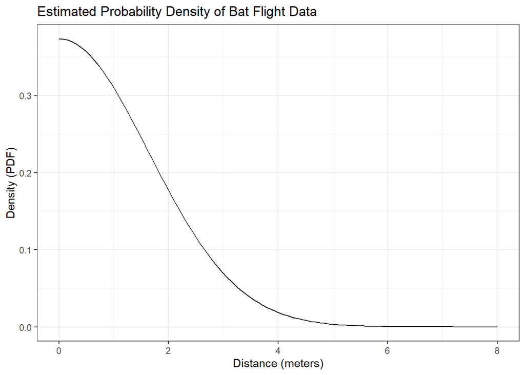

```r
evaluation_points <- seq(0, 8, length.out=100)

# function to create pdf for theta
pdf_theta <- function(x, theta) {
  return(1/theta * exp(-x^2/(2*theta)))
}

# get est density over a sequence of points
estimated_density <- pdf_theta(evaluation_points, mle_theta)

# results into df for plotting
df <- data.frame(distance=evaluation_points, density=estimated_density)

# Plot the estimated density
ggplot(df, aes(x=distance, y=density)) +
  geom_line() +
  labs(x = "Distance (meters)", y = "Density (PDF)", title = "Estimated Probability Density of Bat Flight Data")
```

## d. Estimate the density using KDE.

Report the bandwidth you selected and produce a plot of the estimated density.

**Solution**

[figure not shown]

```r
# using vanilla R density function to calculate KDE
kde <- density(evaluation_points, bw="ucv") # "ucv"==unbiased cross-validation; options include "bcv", "nrd", "nrd0"

# Plot the estimated density
ggplot(data.frame(x=kde$x, y=kde$y), aes(x=x, y=y)) +
  geom_line() +
  labs(x = "Distance (meters)", y = "Density",
       title = "Kernel Density Estimate of Bat Flight Data",
       subtitle = sprintf("Bandwidth (Unbiased Cross-Validation): %.3f", kde$bw)) +
  theme_minimal()
```

```r
cat("Bandwidth used:", kde$bw, "\n")
```

```
Bandwidth used: 1.06
```

## e. Which model do you prefer, the parametric or KDE?

**Solution**

The Kernel Density Estimate model is more immediately visually intuitive. A parametric curve is less interpretable; most readers will probably need to apply a degree of effort to translate it.

# Problem 2: Interstate Crash Density

Interstate 64 (I-64) is a major east-west road that passes just south of Charlottesville. Where and when are the most dangerous places/times to be on I-64? The crash data (link below) gives the mile marker and fractional time-of-week for crashes that occurred on I-64 between mile marker 87 and 136 in 2016. The time-of-week data takes a numeric value of *<dow>.<hour/24>*, where the dow starts at 0 for Sunday (6 for Sat) and the decimal gives the time of day information. Thus `time=0.0417` corresponds to Sun at 1am and `time=6.5` corresponds to Sat at noon.

- **Crash Data**: https://mdporter.github.io/SYS6018/data//crashes16.csv

## a. Crash Data

Extract the crashes and make a scatter plot with mile marker on x-axis and time on y-axis.

**Solution**

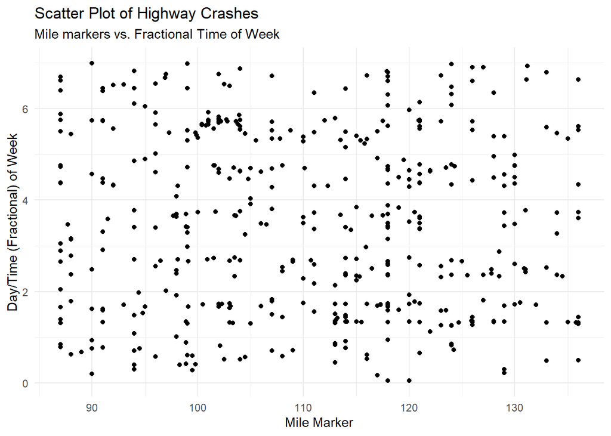

```r
ggplot(crashes, aes(x=mile, y=time)) +
  geom_point() +
  labs(x = "Mile Marker", y = "Day/Time (Fractional) of Week",
       title = "Scatter Plot of Highway Crashes",
       subtitle = "Mile markers vs. Fractional Time of Week") +
  theme_minimal()
```

## b. Use KDE to estimate the *mile marker* density.

- Report the bandwidth.
- Plot the density estimate.

**Solution**

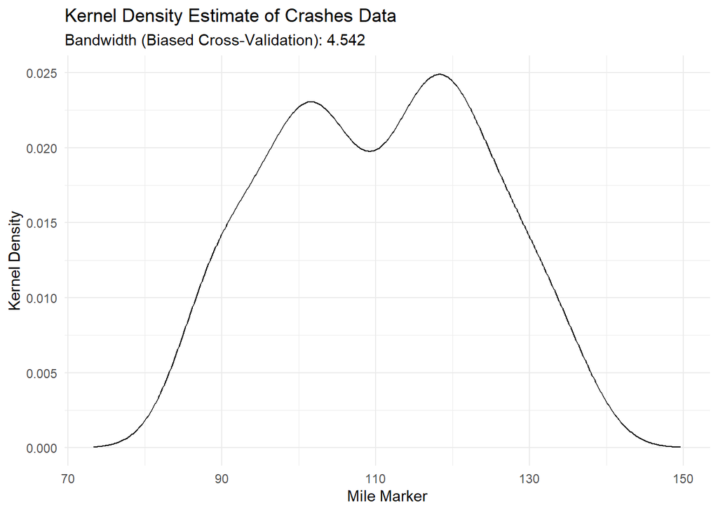

```r
# using vanilla R density function to calculate KDE
kde <- density(crashes$mile, bw="bcv") # "bcv"==biased cross-validation; options include "ucv", "nrd", "nrd0"

# Plot the estimated density
ggplot(data.frame(x=kde$x, y=kde$y), aes(x=x, y=y)) +
  geom_line() +
  labs(x = "Mile Marker", y = "Kernel Density",
       title = "Kernel Density Estimate of Crashes Data",
       subtitle = sprintf("Bandwidth (Biased Cross-Validation): %.3f", kde$bw)) +
  theme_minimal()
```

```r
cat("Bandwidth used:", kde$bw, "\n")
```

```
Bandwidth used: 4.54
```

## c. Use KDE to estimate the temporal *time-of-week* density.

- Report the bandwidth.
- Plot the density estimate.

**Solution**

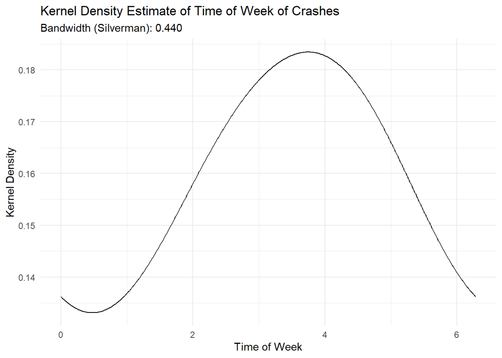

```r
# circular library for handling time-of-week data, which is circular (i.e. wraps around)
library(circular)
crashes$time.rad <- crashes$time * 2 * pi  # Convert time to radians for circular KDE
time_data_circular <- circular(crashes$time.rad, units="radians")

# estimate bandwidth using Silverman's rule of thumb
h <- (4/(3*length(time_data_circular)))^(1/5) * sd(time_data_circular)

# estimate kde of circular data using default "nrd0" bw method
circular_kde <- density.circular(time_data_circular, bw=h)

ggplot(data.frame(x=circular_kde$x, y=circular_kde$y), aes(x=x, y=y)) +
  geom_line() +
  labs(x="Time of Week", y="Kernel Density",
       title = "Kernel Density Estimate of Time of Week of Crashes",
       subtitle = sprintf("Bandwidth (Silverman): %.3f", circular_kde$bw)) +
  theme_minimal()
```

```r
cat("Bandwidth used:", circular_kde$bw, "\n")
```

```
Bandwidth used: 0.44
```

## d. Use KDE to estimate the bivariate mile-time density.

- Report the bandwidth parameters.
- Plot the bivariate density estimate.

**Solution**

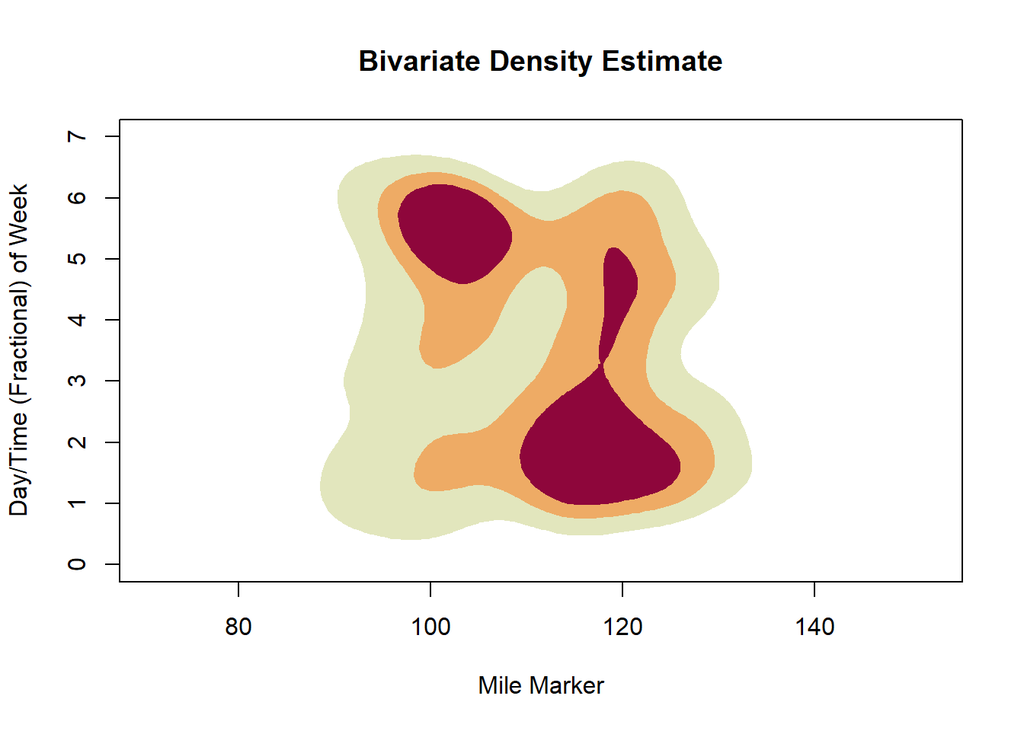

```r
data_matrix <- as.matrix(data.frame(x=crashes$mile, y=crashes$time))

# Compute bivariate KDE using ks library KDE function
bivariate_kde <- kde(data_matrix)

# Plot bivariate KDE
plot(bivariate_kde, display="filled.contour",
     main="Bivariate Density Estimate",
     ylim = c(0, 7),
     xlab = "Mile Marker", ylab = "Day/Time (Fractional) of Week")
```

```r
cat("Bandwidth parameters:\n", bivariate_kde$H, "\n")
```

```
Bandwidth parameters:
 19 -0.115 -0.115 0.33
```

## e. Crash Hotspot

Based on the estimated density, approximate the most dangerous place and time to drive on this stretch of road. Identify the mile marker and time-of-week pair (within a few miles and hours).

**Solution**

```r
# Find the indices of the maximum density value
max_indices <- which(bivariate_kde$estimate == max(bivariate_kde$estimate), arr.ind=TRUE)

# Extract the most dangerous point coordinates
most_dangerous_mile_marker <- bivariate_kde$eval.points[[1]][max_indices[1]]
most_dangerous_time <- bivariate_kde$eval.points[[2]][max_indices[2]]

# Report the most dangerous place and time
cat("Most dangerous mile marker:", most_dangerous_mile_marker, "\n")
```

```
Most dangerous mile marker: 102
```

```r
cat("Most dangerous time of week:", most_dangerous_time, "≈ Friday 12:46 p.m.\n")
```

```
Most dangerous time of week: 5.53 ≈ Friday 12:46 p.m.
```